# Supplementary Information: GAM Models

# Zoonoses GAM - All Associations

Terms in models with ΔAIC < 2. All continuous terms effects are represented as splines, all discrete terms as random effects:

| ΔAIC | Terms in Model |
| --- | --- |
| 0.000000 | offset(LnTotNumVirus) + hDiseaseZACitesLn + hHuntedIUCN + hOrderCETARTIODACTYLA + hOrderCHIROPTERA + hOrderDIPROTODONTIA + hOrderPERAMELEMORPHIA + hOrderPERISSODACTYLA + hOrderSCANDENTIA + PdHoSa.cbCs… |
| 1.665814 | offset(LnTotNumVirus) + hDiseaseZACitesLn + hHuntedIUCN + hOrderCETARTIODACTYLA + hOrderCHIROPTERA + hOrderDIPROTODONTIA + hOrderPERAMELEMORPHIA + hOrderPERISSODACTYLA + hOrderSCANDENTIA + PdHoSaSTPD … |

Partial effect plots of all terms in top model:

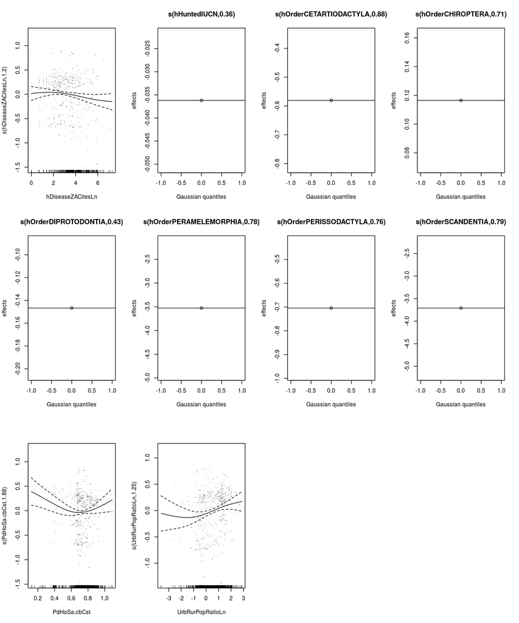

Summary of top model:

```
##
## Family: poisson
## Link function: log
##
## Formula:
## NSharedWithHoSa ~ s(hDiseaseZACitesLn, bs = "tp", k = 7) + s(hHuntedIUCN,
##     bs = "re") + s(hOrderCETARTIODACTYLA, bs = "re") + s(hOrderCHIROPTERA,
##     bs = "re") + s(hOrderDIPROTODONTIA, bs = "re") + s(hOrderPERAMELEMORPHIA,
##     bs = "re") + s(hOrderPERISSODACTYLA, bs = "re") + s(hOrderSCANDENTIA,
##     bs = "re") + s(PdHoSa.cbCst, bs = "tp", k = 7) + s(UrbRurPopRatioLn,
##     bs = "tp", k = 7) + offset(LnTotNumVirus)
##
## Parametric coefficients:
##             Estimate Std. Error z value Pr(>|z|)
## (Intercept)  -0.3384     0.0408  -8.295   <2e-16 ***
## ---
## Signif. codes:  0 '***' 0.001 '**' 0.01 '*' 0.05 '.' 0.1 ' ' 1
##
## Approximate significance of smooth terms:
##                             edf Ref.df Chi.sq  p-value
## s(hDiseaseZACitesLn)     1.2036      6  5.806  0.01713 *
## s(hHuntedIUCN)           0.3604      1  0.748  0.16709
## s(hOrderCETARTIODACTYLA) 0.8846      1 27.143 9.16e-08 ***
## s(hOrderCHIROPTERA)      0.7060      1  4.428  0.01501 *
## s(hOrderDIPROTODONTIA)   0.4276      1  0.720  0.19412
## s(hOrderPERAMELEMORPHIA) 0.7791      1  0.760  0.32332
## s(hOrderPERISSODACTYLA)  0.7632      1  3.278  0.03868 *
## s(hOrderSCANDENTIA)      0.7876      1  0.808  0.31103
## s(PdHoSa.cbCst)          1.8828      6 12.706  0.00189 **
## s(UrbRurPopRatioLn)      1.2486      6 10.013  0.00200 **
## ---
## Signif. codes:  0 '***' 0.001 '**' 0.01 '*' 0.05 '.' 0.1 ' ' 1
##
## R-sq.(adj) =   0.89   Deviance explained =   33%
## UBRE = -0.59911  Scale est. = 1         n = 584
```

Relative fraction of deviance explained by each variable in the top model:

| Term | Relative Deviance Explained |
| --- | --- |
| hDiseaseZACitesLn | 7.74% |
| hHuntedIUCN | 1.31% |
| hOrderCETARTIODACTYLA | 36.3% |
| hOrderCHIROPTERA | 6.53% |
| hOrderDIPROTODONTIA | 1.72% |
| hOrderPERAMELEMORPHIA | 4.8% |
| hOrderPERISSODACTYLA | 6.35% |
| hOrderSCANDENTIA | 5.33% |
| PdHoSa.cbCst | 16.9% |
| UrbRurPopRatioLn | 13% |

10-fold cross-validation. Good fit indicated by *non*-significant p-values:

| Fold | Observations Fit | Observations Held Out | P-value | Mean Error |
| --- | --- | --- | --- | --- |
| 1 | 525 | 59 | 0.774 | -0.0338373 |
| 2 | 525 | 59 | 0.837 | 0.0284172 |
| 3 | 525 | 59 | 0.292 | 0.1053886 |
| 4 | 525 | 59 | 0.407 | -0.0794233 |
| 5 | 526 | 58 | 0.602 | 0.0595194 |
| 6 | 526 | 58 | 0.079 | 0.1897663 |
| 7 | 526 | 58 | 0.086 | -0.1919741 |
| 8 | 526 | 58 | 0.124 | -0.2213560 |
| 9 | 526 | 58 | 0.494 | 0.0634252 |
| 10 | 526 | 58 | 0.646 | -0.0554972 |

# Zoonoses GAM - Strict Associations

Terms in models with ΔAIC < 2. All continuous terms effects are represented as splines, all discrete terms as random effects:

| ΔAIC | Terms in Model |
| --- | --- |
| 0 | offset(LnTotNumVirus) + hDiseaseZACitesLn + hMassGramsPVR + hOrderCETARTIODACTYLA + hOrderDIPROTODONTIA + hOrderLAGOMORPHA + hOrderPERISSODACTYLA + hOrderPRIMATES + HumPopDensLnChg + PdHoSa.cbCst + Ur… |

Partial effect plots of all terms in top model:

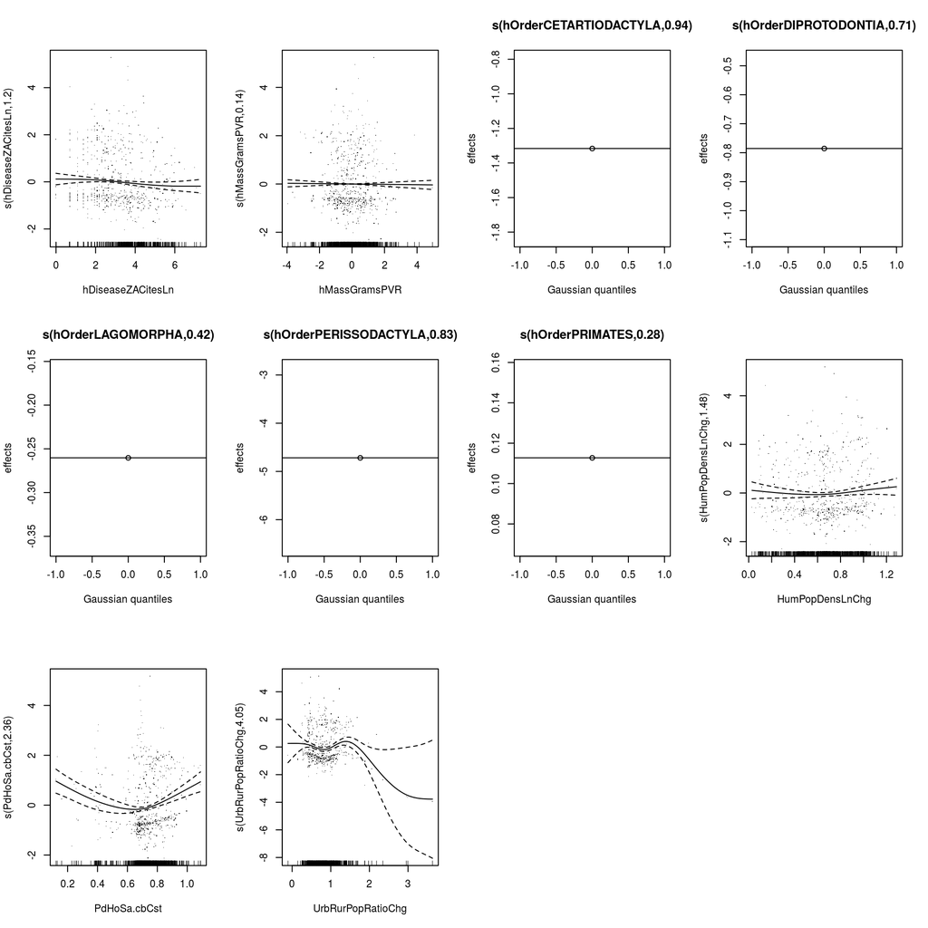

Summary of top model:

```
##
## Family: poisson
## Link function: log
##
## Formula:
## NSharedWithHoSa_strict ~ s(hDiseaseZACitesLn, bs = "tp", k = 7) +
##     s(hMassGramsPVR, bs = "tp", k = 7) + s(hOrderCETARTIODACTYLA,
##     bs = "re") + s(hOrderDIPROTODONTIA, bs = "re") + s(hOrderLAGOMORPHA,
##     bs = "re") + s(hOrderPERISSODACTYLA, bs = "re") + s(hOrderPRIMATES,
##     bs = "re") + s(HumPopDensLnChg, bs = "tp", k = 7) + s(PdHoSa.cbCst,
##     bs = "tp", k = 7) + s(UrbRurPopRatioChg, bs = "tp", k = 7) +
##     offset(LnTotNumVirus)
##
## Parametric coefficients:
##             Estimate Std. Error z value Pr(>|z|)
## (Intercept) -1.34882    0.05948  -22.68   <2e-16 ***
## ---
## Signif. codes:  0 '***' 0.001 '**' 0.01 '*' 0.05 '.' 0.1 ' ' 1
##
## Approximate significance of smooth terms:
##                             edf Ref.df Chi.sq  p-value
## s(hDiseaseZACitesLn)     1.1991      6  4.926  0.01507 *
## s(hMassGramsPVR)         0.1419      6  0.155  0.28660
## s(hOrderCETARTIODACTYLA) 0.9432      1 22.981 7.28e-07 ***
## s(hOrderDIPROTODONTIA)   0.7081      1  2.393  0.06578 .
## s(hOrderLAGOMORPHA)      0.4220      1  0.707  0.19515
## s(hOrderPERISSODACTYLA)  0.8250      1  0.863  0.30654
## s(hOrderPRIMATES)        0.2779      1  0.599  0.09857 .
## s(HumPopDensLnChg)       1.4848      6  3.226  0.12828
## s(PdHoSa.cbCst)          2.3631      6 56.003 7.63e-06 ***
## s(UrbRurPopRatioChg)     4.0467      6 16.919  0.00205 **
## ---
## Signif. codes:  0 '***' 0.001 '**' 0.01 '*' 0.05 '.' 0.1 ' ' 1
##
## R-sq.(adj) =  0.655   Deviance explained = 23.6%
## UBRE = -0.15761  Scale est. = 1         n = 576
```

Relative fraction of deviance explained by each variable in the top model:

| Term | Relative Deviance Explained |
| --- | --- |
| hDiseaseZACitesLn | 3.76% |
| hMassGramsPVR | 1.12% |
| hOrderCETARTIODACTYLA | 28% |
| hOrderDIPROTODONTIA | 2.75% |
| hOrderLAGOMORPHA | 0.881% |
| hOrderPERISSODACTYLA | 5% |
| hOrderPRIMATES | 0.101% |
| HumPopDensLnChg | 4.34% |
| PdHoSa.cbCst | 34.5% |
| UrbRurPopRatioChg | 19.6% |

10-fold cross-validation. Good fit indicated by *non*-significant p-values:

| Fold | Observations Fit | Observations Held Out | P-value | Mean Error |
| --- | --- | --- | --- | --- |
| 1 | 518 | 58 | 0.060 | 0.2067273 |
| 2 | 518 | 58 | 0.753 | 0.0326309 |
| 3 | 518 | 58 | 0.128 | -0.1412644 |
| 4 | 518 | 58 | 0.488 | -0.0538109 |
| 5 | 518 | 58 | 0.426 | 0.0893661 |
| 6 | 518 | 58 | 0.100 | -0.1518292 |
| 7 | 519 | 57 | 0.845 | -0.0232406 |
| 8 | 519 | 57 | 0.966 | 0.0082874 |
| 9 | 519 | 57 | 0.212 | 0.1282004 |
| 10 | 519 | 57 | 0.650 | -0.1509012 |

# Zoonoses GAM - All Associations without Reverse Zoonoses

Terms in models with ΔAIC < 2. All continuous terms effects are represented as splines, all discrete terms as random effects:

| ΔAIC | Terms in Model |
| --- | --- |
| 0.0000000 | offset(LnTotNumVirus) + hDiseaseZACitesLn + hHuntedIUCN + hOrderCETARTIODACTYLA + hOrderCHIROPTERA + hOrderDIPROTODONTIA + hOrderPERAMELEMORPHIA + hOrderPERISSODACTYLA + hOrderSCANDENTIA + HumPopDensL… |
| 0.6945356 | offset(LnTotNumVirus) + hDiseaseZACitesLn + hHuntedIUCN + hOrderCETARTIODACTYLA + hOrderCHIROPTERA + hOrderDIPROTODONTIA + hOrderPERAMELEMORPHIA + hOrderPERISSODACTYLA + hOrderSCANDENTIA + PdHoSa.cbCs… |

Partial effect plots of all terms in top model:

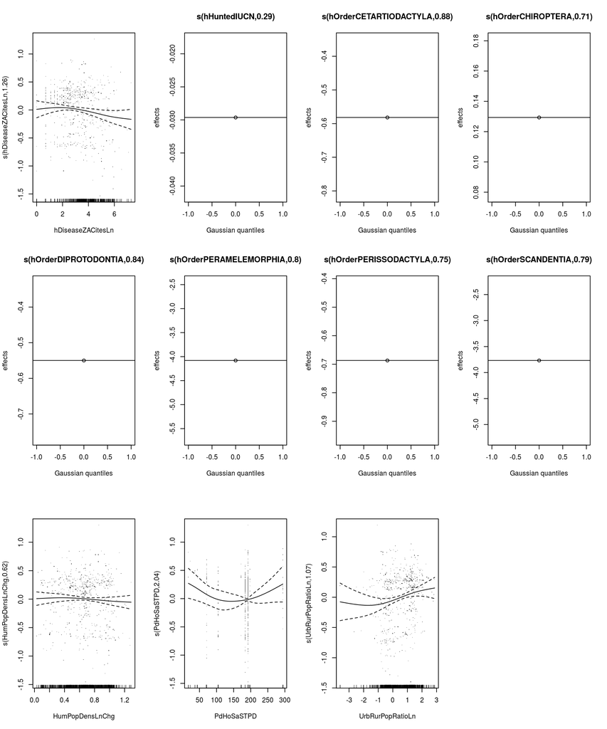

Summary of top model:

```
##
## Family: poisson
## Link function: log
##
## Formula:
## NSharedWithHoSa_norev ~ s(hDiseaseZACitesLn, bs = "tp", k = 7) +
##     s(hHuntedIUCN, bs = "re") + s(hOrderCETARTIODACTYLA, bs = "re") +
##     s(hOrderCHIROPTERA, bs = "re") + s(hOrderDIPROTODONTIA, bs = "re") +
##     s(hOrderPERAMELEMORPHIA, bs = "re") + s(hOrderPERISSODACTYLA,
##     bs = "re") + s(hOrderSCANDENTIA, bs = "re") + s(HumPopDensLnChg,
##     bs = "tp", k = 7) + s(PdHoSaSTPD, bs = "tp", k = 7) + s(UrbRurPopRatioLn,
##     bs = "tp", k = 7) + offset(LnTotNumVirus)
##
## Parametric coefficients:
##             Estimate Std. Error z value Pr(>|z|)
## (Intercept) -0.35041    0.04169  -8.405   <2e-16 ***
## ---
## Signif. codes:  0 '***' 0.001 '**' 0.01 '*' 0.05 '.' 0.1 ' ' 1
##
## Approximate significance of smooth terms:
##                             edf Ref.df Chi.sq  p-value
## s(hDiseaseZACitesLn)     1.2616      6  6.274  0.01433 *
## s(hHuntedIUCN)           0.2889      1  0.635  0.15443
## s(hOrderCETARTIODACTYLA) 0.8798      1 27.139 1.22e-07 ***
## s(hOrderCHIROPTERA)      0.7095      1  5.338  0.00919 **
## s(hOrderDIPROTODONTIA)   0.8398      1  3.450  0.03829 *
## s(hOrderPERAMELEMORPHIA) 0.8030      1  0.739  0.33733
## s(hOrderPERISSODACTYLA)  0.7514      1  3.196  0.04004 *
## s(hOrderSCANDENTIA)      0.7902      1  0.799  0.31466
## s(HumPopDensLnChg)       0.6211      6  1.082  0.16857
## s(PdHoSaSTPD)            2.0424      6 12.117  0.05375 .
## s(UrbRurPopRatioLn)      1.0721      6  9.320  0.00154 **
## ---
## Signif. codes:  0 '***' 0.001 '**' 0.01 '*' 0.05 '.' 0.1 ' ' 1
##
## R-sq.(adj) =  0.879   Deviance explained = 31.5%
## UBRE = -0.57415  Scale est. = 1         n = 583
```

Relative fraction of deviance explained by each variable in the top model:

| Term | Relative Deviance Explained |
| --- | --- |
| hDiseaseZACitesLn | 10.5% |
| hHuntedIUCN | 1.27% |
| hOrderCETARTIODACTYLA | 33% |
| hOrderCHIROPTERA | 5.14% |
| hOrderDIPROTODONTIA | 5.43% |
| hOrderPERAMELEMORPHIA | 6.42% |
| hOrderPERISSODACTYLA | 6.18% |
| hOrderSCANDENTIA | 5.77% |
| HumPopDensLnChg | 3.37% |
| PdHoSaSTPD | 14.5% |
| UrbRurPopRatioLn | 8.4% |

10-fold cross-validation. Good fit indicated by *non*-significant p-values:

| Fold | Observations Fit | Observations Held Out | P-value | Mean Error |
| --- | --- | --- | --- | --- |
| 1 | 524 | 59 | 0.641 | -0.0647548 |
| 2 | 524 | 59 | 0.117 | -0.2187922 |
| 3 | 524 | 59 | 0.253 | 0.1571678 |
| 4 | 525 | 58 | 0.770 | 0.0251143 |
| 5 | 525 | 58 | 0.937 | -0.0092996 |
| 6 | 525 | 58 | 0.914 | 0.0114925 |
| 7 | 525 | 58 | 0.019 | 0.1649511 |
| 8 | 525 | 58 | 0.363 | -0.1333664 |
| 9 | 525 | 58 | 0.258 | 0.0813138 |
| 10 | 525 | 58 | 0.609 | -0.0534845 |

# All Viruses GAM - All Associations

Terms in models with ΔAIC < 2. All continuous terms effects are represented as splines, all discrete terms as random effects:

| ΔAIC | Terms in Model |
| --- | --- |
| 0 | hDiseaseZACitesLn + hMassGramsPVR + hOrderCETARTIODACTYLA + hOrderCHIROPTERA + hOrderEULIPOTYPHLA + hOrderPERISSODACTYLA + hOrderPRIMATES + hOrderRODENTIA + LnAreaHost + S20 |

Partial effect plots of all terms in top model:

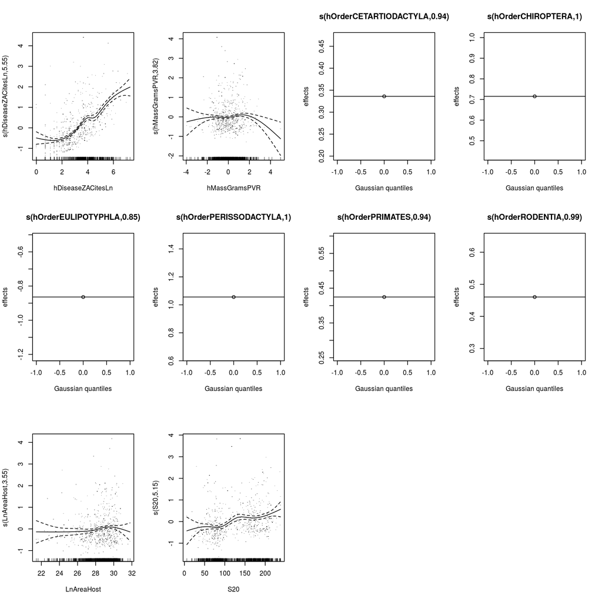

Summary of top model:

```
##
## Family: poisson
## Link function: log
##
## Formula:
## TotVirusPerHost ~ s(hDiseaseZACitesLn, bs = "cs", k = 7) + s(hMassGramsPVR,
##     bs = "cs", k = 7) + s(hOrderCETARTIODACTYLA, bs = "re") +
##     s(hOrderCHIROPTERA, bs = "re") + s(hOrderEULIPOTYPHLA, bs = "re") +
##     s(hOrderPERISSODACTYLA, bs = "re") + s(hOrderPRIMATES, bs = "re") +
##     s(hOrderRODENTIA, bs = "re") + s(LnAreaHost, bs = "cs", k = 7) +
##     s(S20, bs = "cs", k = 7)
##
## Parametric coefficients:
##             Estimate Std. Error z value Pr(>|z|)
## (Intercept)  0.51831    0.06972   7.434 1.05e-13 ***
## ---
## Signif. codes:  0 '***' 0.001 '**' 0.01 '*' 0.05 '.' 0.1 ' ' 1
##
## Approximate significance of smooth terms:
##                             edf Ref.df   Chi.sq  p-value
## s(hDiseaseZACitesLn)     5.5543      6 1835.357  < 2e-16 ***
## s(hMassGramsPVR)         3.8164      6  214.552 0.008832 **
## s(hOrderCETARTIODACTYLA) 0.9368      1   24.561 0.000222 ***
## s(hOrderCHIROPTERA)      1.0000      1  154.876 2.62e-16 ***
## s(hOrderEULIPOTYPHLA)    0.8484      1    5.877 0.008897 **
## s(hOrderPERISSODACTYLA)  0.9999      1    9.894 0.001357 **
## s(hOrderPRIMATES)        0.9433      1   34.523 1.49e-05 ***
## s(hOrderRODENTIA)        0.9943      1   94.871 9.26e-09 ***
## s(LnAreaHost)            3.5512      6   18.872 0.025115 *
## s(S20)                   5.1545      6  301.117 7.34e-15 ***
## ---
## Signif. codes:  0 '***' 0.001 '**' 0.01 '*' 0.05 '.' 0.1 ' ' 1
##
## R-sq.(adj) =  0.494   Deviance explained = 49.2%
## UBRE = 0.36253  Scale est. = 1         n = 576
```

Relative fraction of deviance explained by each variable in the top model:

| Term | Relative Deviance Explained |
| --- | --- |
| hDiseaseZACitesLn | 64.8% |
| hMassGramsPVR | 1.91% |
| hOrderCETARTIODACTYLA | 1.86% |
| hOrderCHIROPTERA | 9.94% |
| hOrderEULIPOTYPHLA | 1.08% |
| hOrderPERISSODACTYLA | 1.41% |
| hOrderPRIMATES | 2.52% |
| hOrderRODENTIA | 4.79% |
| LnAreaHost | 1.58% |
| S20 | 10.1% |

10-fold cross-validation. Good fit indicated by *non*-significant p-values:

| Fold | Observations Fit | Observations Held Out | P-value | Mean Error |
| --- | --- | --- | --- | --- |
| 1 | 518 | 58 | 0.054 | 0.8418053 |
| 2 | 518 | 58 | 0.341 | -0.2544861 |
| 3 | 518 | 58 | 0.720 | -0.0956868 |
| 4 | 518 | 58 | 0.231 | 0.5618381 |
| 5 | 518 | 58 | 0.460 | 0.2390525 |
| 6 | 518 | 58 | 0.011 | -0.7255859 |
| 7 | 519 | 57 | 0.475 | -0.2585722 |
| 8 | 519 | 57 | 0.237 | -0.3077263 |
| 9 | 519 | 57 | 0.112 | -0.4101410 |
| 10 | 519 | 57 | 0.150 | 0.5043752 |

# All Viruses GAM - Strict Associations

Terms in models with ΔAIC < 2. All continuous terms effects are represented as splines, all discrete terms as random effects:

| ΔAIC | Terms in Model |
| --- | --- |
| 0 | hDiseaseZACitesLn + hMassGramsPVR + hOrderCHIROPTERA + hOrderCINGULATA + hOrderEULIPOTYPHLA + hOrderPERAMELEMORPHIA + hOrderPRIMATES + hOrderRODENTIA + hOrderSCANDENTIA + LnAreaHost + S20 |

Partial effect plots of all terms in top model:

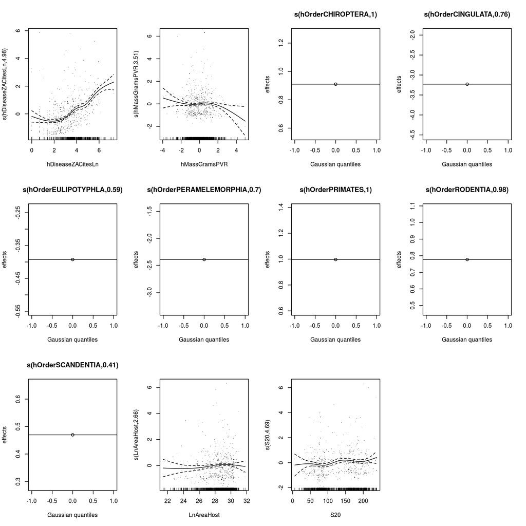

Summary of top model:

```
##
## Family: poisson
## Link function: log
##
## Formula:
## TotVirusPerHost_strict ~ s(hDiseaseZACitesLn, bs = "cs", k = 7) +
##     s(hMassGramsPVR, bs = "cs", k = 7) + s(hOrderCHIROPTERA,
##     bs = "re") + s(hOrderCINGULATA, bs = "re") + s(hOrderEULIPOTYPHLA,
##     bs = "re") + s(hOrderPERAMELEMORPHIA, bs = "re") + s(hOrderPRIMATES,
##     bs = "re") + s(hOrderRODENTIA, bs = "re") + s(hOrderSCANDENTIA,
##     bs = "re") + s(LnAreaHost, bs = "cs", k = 7) + s(S20, bs = "cs",
##     k = 7)
##
## Parametric coefficients:
##             Estimate Std. Error z value Pr(>|z|)
## (Intercept) -0.46813    0.08818  -5.309  1.1e-07 ***
## ---
## Signif. codes:  0 '***' 0.001 '**' 0.01 '*' 0.05 '.' 0.1 ' ' 1
##
## Approximate significance of smooth terms:
##                             edf Ref.df  Chi.sq  p-value
## s(hDiseaseZACitesLn)     4.9780      6 922.796  < 2e-16 ***
## s(hMassGramsPVR)         3.5116      6   9.625 0.035789 *
## s(hOrderCHIROPTERA)      0.9999      1 109.198 5.16e-14 ***
## s(hOrderCINGULATA)       0.7633      1   0.868 0.286333
## s(hOrderEULIPOTYPHLA)    0.5878      1   1.200 0.151800
## s(hOrderPERAMELEMORPHIA) 0.7049      1   0.737 0.306652
## s(hOrderPRIMATES)        0.9998      1  85.101 4.95e-14 ***
## s(hOrderRODENTIA)        0.9767      1 129.267 8.70e-15 ***
## s(hOrderSCANDENTIA)      0.4108      1   0.941 0.129969
## s(LnAreaHost)            2.6550      6  11.139 0.078909 .
## s(S20)                   4.6938      6  44.989 0.000479 ***
## ---
## Signif. codes:  0 '***' 0.001 '**' 0.01 '*' 0.05 '.' 0.1 ' ' 1
##
## R-sq.(adj) =  0.419   Deviance explained = 35.8%
## UBRE =   0.38  Scale est. = 1         n = 575
```

Relative fraction of deviance explained by each variable in the top model:

| Term | Relative Deviance Explained |
| --- | --- |
| hDiseaseZACitesLn | 53.6% |
| hMassGramsPVR | 2.76% |
| hOrderCHIROPTERA | 12.2% |
| hOrderCINGULATA | 0.563% |
| hOrderEULIPOTYPHLA | 0.369% |
| hOrderPERAMELEMORPHIA | 0.362% |
| hOrderPRIMATES | 11.8% |
| hOrderRODENTIA | 12.6% |
| hOrderSCANDENTIA | 0.287% |
| LnAreaHost | 1.53% |
| S20 | 3.91% |

10-fold cross-validation. Good fit indicated by *non*-significant p-values:

| Fold | Observations Fit | Observations Held Out | P-value | Mean Error |
| --- | --- | --- | --- | --- |
| 1 | 517 | 58 | 0.986 | -0.0030748 |
| 2 | 517 | 58 | 0.602 | -0.0857512 |
| 3 | 517 | 58 | 0.308 | 0.2679808 |
| 4 | 517 | 58 | 0.091 | -0.3217388 |
| 5 | 517 | 58 | 0.666 | -0.0903830 |
| 6 | 518 | 57 | 0.643 | 0.1230466 |
| 7 | 518 | 57 | 0.663 | 0.1210772 |
| 8 | 518 | 57 | 0.370 | 0.2459483 |
| 9 | 518 | 57 | 0.733 | -0.0599746 |
| 10 | 518 | 57 | 0.114 | -0.4076403 |

# Viral Traits GAM - All Associations

Terms in models with ΔAIC < 2. All continuous terms effects are represented as splines, all discrete terms as random effects:

| ΔAIC | Terms in Model |
| --- | --- |
| 0 | cb_dist_noHoSa_maxLn + Envelope + vCytoReplicTF + Vector + vGenomeAveLengthLn + vWOKcitesLn |

Partial effect plots of all terms in top model:

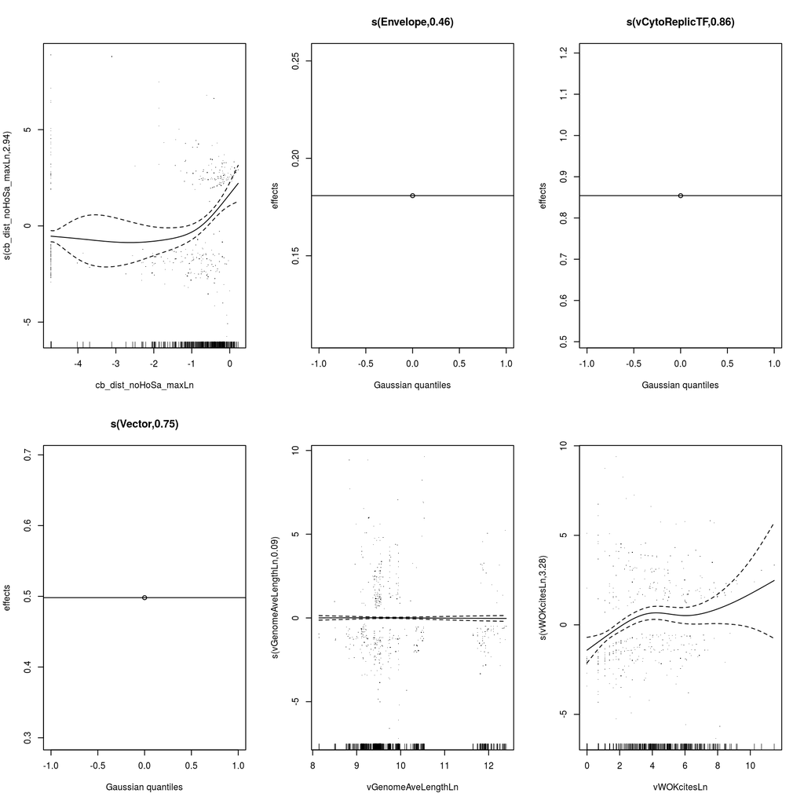

Summary of top model:

```
##
## Family: binomial
## Link function: logit
##
## Formula:
## IsZoonotic ~ s(cb_dist_noHoSa_maxLn, bs = "tp", k = 7) + s(Envelope,
##     bs = "re") + s(vCytoReplicTF, bs = "re") + s(Vector, bs = "re") +
##     s(vGenomeAveLengthLn, bs = "tp", k = 7) + s(vWOKcitesLn,
##     bs = "tp", k = 7)
##
## Parametric coefficients:
##             Estimate Std. Error z value Pr(>|z|)
## (Intercept)  -1.5864     0.2786  -5.693 1.24e-08 ***
## ---
## Signif. codes:  0 '***' 0.001 '**' 0.01 '*' 0.05 '.' 0.1 ' ' 1
##
## Approximate significance of smooth terms:
##                             edf Ref.df Chi.sq  p-value
## s(cb_dist_noHoSa_maxLn) 2.94210      6 44.910 7.48e-10 ***
## s(Envelope)             0.45964      1  0.884 0.166460
## s(vCytoReplicTF)        0.85868      1 10.956 0.000854 ***
## s(Vector)               0.75131      1  4.901 0.014258 *
## s(vGenomeAveLengthLn)   0.09239      6  0.117 0.265718
## s(vWOKcitesLn)          3.28464      6 35.828 3.98e-07 ***
## ---
## Signif. codes:  0 '***' 0.001 '**' 0.01 '*' 0.05 '.' 0.1 ' ' 1
##
## R-sq.(adj) =  0.313   Deviance explained = 27.2%
## UBRE = 0.002481  Scale est. = 1         n = 464
```

Relative fraction of deviance explained by each variable in the top model:

| Term | Relative Deviance Explained |
| --- | --- |
| cb_dist_noHoSa_maxLn | 45.6% |
| Envelope | 2.32% |
| vCytoReplicTF | 9.15% |
| Vector | 4.61% |
| vGenomeAveLengthLn | 0.946% |
| vWOKcitesLn | 37.4% |

10-fold cross-validation. Good fit indicated by *non*-significant p-values:

| Fold | Observations Fit | Observations Held Out | P-value | Mean Error |
| --- | --- | --- | --- | --- |
| 1 | 417 | 47 | 0.628 | 0.0284356 |
| 2 | 417 | 47 | 0.432 | -0.0415209 |
| 3 | 417 | 47 | 0.894 | -0.0087684 |
| 4 | 417 | 47 | 0.991 | 0.0007085 |
| 5 | 418 | 46 | 0.039 | 0.1382797 |
| 6 | 418 | 46 | 0.985 | 0.0012093 |
| 7 | 418 | 46 | 0.578 | 0.0327124 |
| 8 | 418 | 46 | 0.702 | -0.0232710 |
| 9 | 418 | 46 | 0.175 | -0.0936055 |
| 10 | 418 | 46 | 0.482 | -0.0374536 |

# Viral Traits GAM - Strict Associations

Terms in models with ΔAIC < 2. All continuous terms effects are represented as splines, all discrete terms as random effects:

| ΔAIC | Terms in Model |
| --- | --- |
| 0.000000 | cb_dist_noHoSa_max.stringentLn + vCytoReplicTF + Vector + vWOKcitesLn |
| 1.600703 | st_dist_noHoSa_max.stringentLn + vCytoReplicTF + Vector + vGenomeAveLengthLn + vWOKcitesLn |
| 1.715616 | cb_dist_noHoSa_mean.stringentLn + vCytoReplicTF + Vector + vWOKcitesLn |
| 1.727325 | cb_dist_noHoSa_median.stringentLn + vCytoReplicTF + Vector + vWOKcitesLn |

Partial effect plots of all terms in top model:

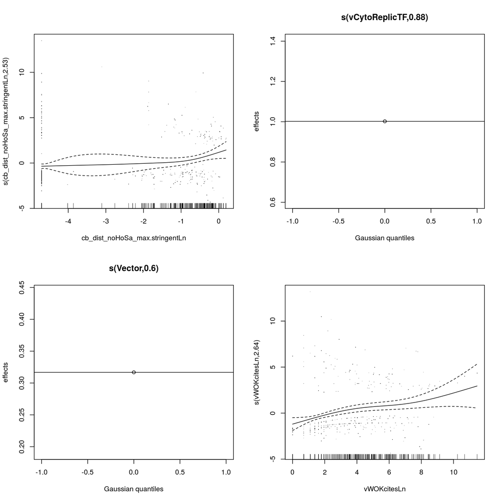

Summary of top model:

```
##
## Family: binomial
## Link function: logit
##
## Formula:
## IsZoonotic.stringent ~ s(cb_dist_noHoSa_max.stringentLn, bs = "tp",
##     k = 7) + s(vCytoReplicTF, bs = "re") + s(Vector, bs = "re") +
##     s(vWOKcitesLn, bs = "tp", k = 7)
##
## Parametric coefficients:
##             Estimate Std. Error z value Pr(>|z|)
## (Intercept)  -2.2312     0.2969  -7.514 5.72e-14 ***
## ---
## Signif. codes:  0 '***' 0.001 '**' 0.01 '*' 0.05 '.' 0.1 ' ' 1
##
## Approximate significance of smooth terms:
##                                      edf Ref.df Chi.sq  p-value
## s(cb_dist_noHoSa_max.stringentLn) 2.5254      6 15.750 0.000556 ***
## s(vCytoReplicTF)                  0.8781      1 10.328 0.001101 **
## s(Vector)                         0.6035      1  1.873 0.085405 .
## s(vWOKcitesLn)                    2.6374      6 29.513  4.3e-07 ***
## ---
## Signif. codes:  0 '***' 0.001 '**' 0.01 '*' 0.05 '.' 0.1 ' ' 1
##
## R-sq.(adj) =  0.225   Deviance explained = 21.1%
## UBRE = -0.092089  Scale est. = 1         n = 408
```

Relative fraction of deviance explained by each variable in the top model:

| Term | Relative Deviance Explained |
| --- | --- |
| cb_dist_noHoSa_max.stringentLn | 25.5% |
| vCytoReplicTF | 17.5% |
| Vector | 3.88% |
| vWOKcitesLn | 53.1% |

10-fold cross-validation. Good fit indicated by *non*-significant p-values:

| Fold | Observations Fit | Observations Held Out | P-value | Mean Error |
| --- | --- | --- | --- | --- |
| 1 | 367 | 41 | 0.530 | -0.0392636 |
| 2 | 367 | 41 | 0.831 | 0.0140749 |
| 3 | 367 | 41 | 0.245 | 0.0730734 |
| 4 | 367 | 41 | 0.830 | -0.0118291 |
| 5 | 367 | 41 | 0.566 | 0.0403362 |
| 6 | 367 | 41 | 0.357 | -0.0488821 |
| 7 | 367 | 41 | 0.322 | -0.0667731 |
| 8 | 367 | 41 | 0.275 | 0.0664279 |
| 9 | 368 | 40 | 0.876 | 0.0092479 |
| 10 | 368 | 40 | 0.307 | -0.0601761 |

# Zoonoses in Domestic Animals GAM - All Associations

Terms in models with ΔAIC < 2. All continuous terms effects are represented as splines, all discrete terms as random effects:

| ΔAIC | Terms in Model |
| --- | --- |
| 0.0000000 | offset(LnTotNumVirus) + domestic_category2 + hOrderCETARTIODACTYLA |
| 0.0413592 | offset(LnTotNumVirus) + domestic_category2 + hOrderCETARTIODACTYLA + hOrderLAGOMORPHA |

Partial effect plots of all terms in top model:

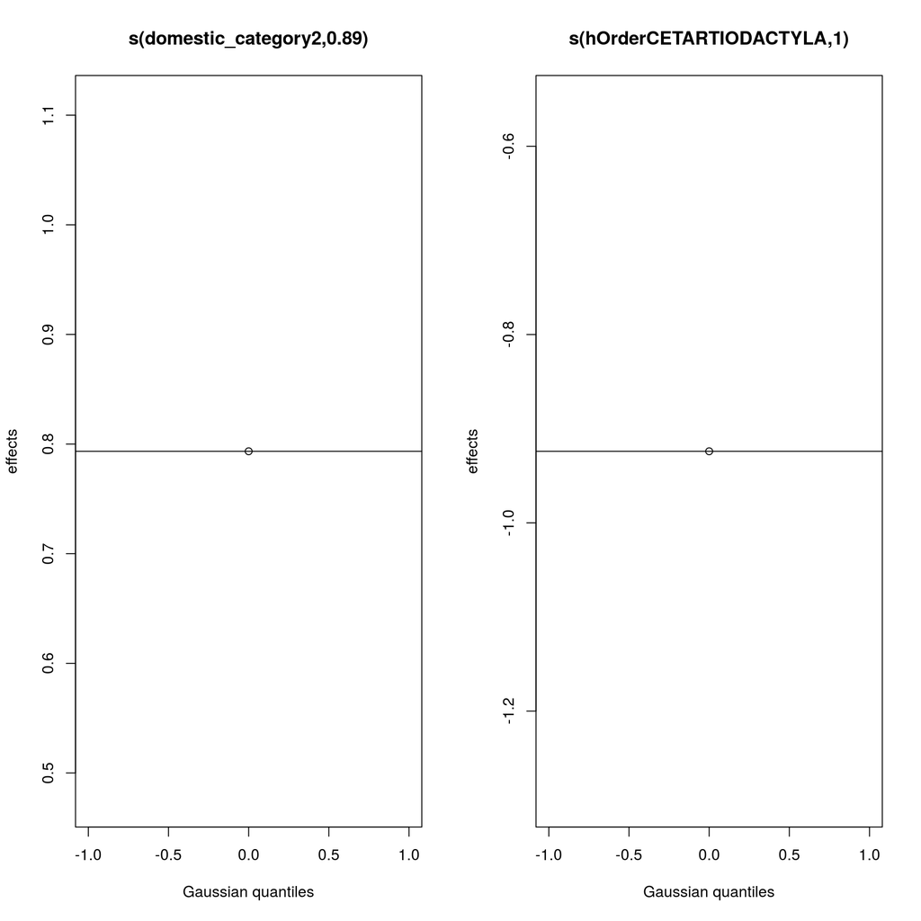

Summary of top model:

```
##
## Family: poisson
## Link function: log
##
## Formula:
## NSharedWithHoSa ~ s(domestic_category2, bs = "re") + s(hOrderCETARTIODACTYLA,
##     bs = "re") + offset(LnTotNumVirus)
##
## Parametric coefficients:
##             Estimate Std. Error z value Pr(>|z|)
## (Intercept) -0.60693    0.09325  -6.509 7.58e-11 ***
## ---
## Signif. codes:  0 '***' 0.001 '**' 0.01 '*' 0.05 '.' 0.1 ' ' 1
##
## Approximate significance of smooth terms:
##                             edf Ref.df Chi.sq p-value
## s(domestic_category2)    0.8861      1  68.07 0.00439 **
## s(hOrderCETARTIODACTYLA) 0.9999      1  97.22 0.00205 **
## ---
## Signif. codes:  0 '***' 0.001 '**' 0.01 '*' 0.05 '.' 0.1 ' ' 1
##
## R-sq.(adj) =   0.96   Deviance explained =   38%
## UBRE = -0.17089  Scale est. = 1         n = 32
```

Relative fraction of deviance explained by each variable in the top model:

| Term | Relative Deviance Explained |
| --- | --- |
| domestic_category2 | 43% |
| hOrderCETARTIODACTYLA | 57% |

10-fold cross-validation. Good fit indicated by *non*-significant p-values:

| Fold | Observations Fit | Observations Held Out | P-value | Mean Error |
| --- | --- | --- | --- | --- |
| 1 | 28 | 4 | 0.748 | 0.3897941 |
| 2 | 28 | 4 | 0.876 | 0.0413904 |
| 3 | 29 | 3 | 0.500 | -0.2523949 |
| 4 | 29 | 3 | 0.250 | 0.5501736 |
| 5 | 29 | 3 | 0.000 | 1.9905346 |
| 6 | 29 | 3 | 0.749 | 1.5312558 |
| 7 | 29 | 3 | 0.249 | -1.4689101 |
| 8 | 29 | 3 | 0.498 | -0.8212953 |
| 9 | 29 | 3 | 0.254 | -2.6681889 |
| 10 | 29 | 3 | 0.000 | -0.8835657 |

# Zoonoses in Domestic Animals GAM - Strict Associations

Terms in models with ΔAIC < 2. All continuous terms effects are represented as splines, all discrete terms as random effects:

| ΔAIC | Terms in Model |
| --- | --- |
| 0.0000000 | offset(LnTotNumVirus) + hOrderLAGOMORPHA + hOrderPROBOSCIDEA + hOrderRODENTIA |
| 0.0005550 | offset(LnTotNumVirus) + hOrderLAGOMORPHA + hOrderPROBOSCIDEA |
| 0.3074961 | offset(LnTotNumVirus) + hOrderLAGOMORPHA + hOrderRODENTIA |
| 0.3115803 | offset(LnTotNumVirus) + hOrderLAGOMORPHA |
| 0.6164310 | offset(LnTotNumVirus) + hOrderPROBOSCIDEA + hOrderRODENTIA |
| 0.6978756 | offset(LnTotNumVirus) + hOrderPROBOSCIDEA |
| 0.7057037 | offset(LnTotNumVirus) + domestic_categoryOther + hOrderPROBOSCIDEA |
| 0.7983515 | offset(LnTotNumVirus) + domestic_category3 + hOrderLAGOMORPHA + hOrderRODENTIA + LnDOMYearBP |
| 0.8305375 | offset(LnTotNumVirus) + domestic_category3 + hOrderRODENTIA + LnDOMYearBP |
| 0.9613857 | offset(LnTotNumVirus) + domestic_category3 + hOrderLAGOMORPHA + hOrderRODENTIA + LnDOMYearBP + PdHoSa.cbCst |
| 1.0015364 | offset(LnTotNumVirus) + hOrderRODENTIA |
| 1.0485809 | offset(LnTotNumVirus) + domestic_category3 + hOrderRODENTIA + LnDOMYearBP + PdHoSa.cbCst |
| 1.0494122 | offset(LnTotNumVirus) + domestic_category3 + hDiseaseZACitesLn + hOrderRODENTIA + LnDOMYearBP |
| 1.0649989 | offset(LnTotNumVirus) + domestic_category3 + hDiseaseZACitesLn + hMassGramsPVR + hOrderRODENTIA + LnDOMYearBP |
| 1.0738794 | +offset(LnTotNumVirus) |
| 1.0738794 | offset(LnTotNumVirus) |
| 1.0741740 | offset(LnTotNumVirus) + domestic_categoryOther |
| 1.0936712 | offset(LnTotNumVirus) + domestic_category3 + hDiseaseZACitesLn + hOrderLAGOMORPHA + hOrderRODENTIA + LnDOMYearBP |
| 1.1123648 | offset(LnTotNumVirus) + domestic_category2 + domestic_category3 + hOrderRODENTIA + LnDOMYearBP |
| 1.4523096 | offset(LnTotNumVirus) + domestic_category2 + domestic_category3 + hOrderRODENTIA + LnDOMYearBP + PdHoSa.cbCst |
| 1.6298513 | offset(LnTotNumVirus) + domestic_category2 + domestic_category3 + hMassGramsPVR + hOrderRODENTIA + LnDOMYearBP + PdHoSa.cbCst |
| 1.6412275 | offset(LnTotNumVirus) + domestic_category2 + domestic_category3 + hDiseaseZACitesLn + hOrderRODENTIA + LnDOMYearBP + PdHoSa.cbCst |
| 1.6436877 | offset(LnTotNumVirus) + domestic_category2 + domestic_category3 + hMassGramsPVR + hOrderRODENTIA + LnDOMYearBP |
| 1.7870691 | offset(LnTotNumVirus) + domestic_category3 + hDiseaseZACitesLn + hOrderLAGOMORPHA + hOrderRODENTIA + LnDOMYearBP + PdHoSa.cbCst |
| 1.7917253 | offset(LnTotNumVirus) + domestic_category3 + domestic_categoryOther + hOrderLAGOMORPHA + LnDOMYearBP |
| 1.9147085 | offset(LnTotNumVirus) + domestic_category3 + domestic_categoryOther + LnDOMYearBP |

Partial effect plots of all terms in top model:

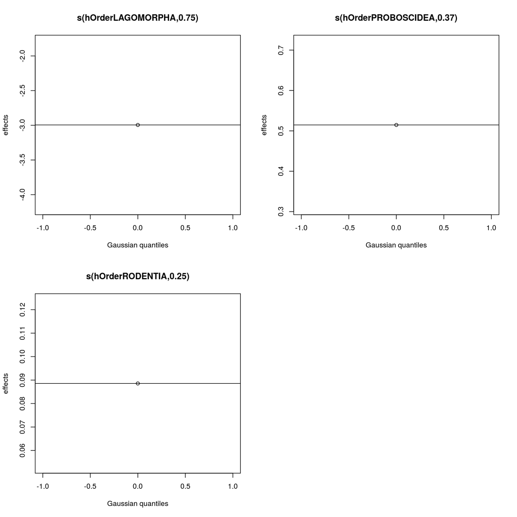

Summary of top model:

```
##
## Family: poisson
## Link function: log
##
## Formula:
## NSharedWithHoSa_strict ~ offset(LnTotNumVirus) + s(hOrderLAGOMORPHA,
##     bs = "re") + s(hOrderPROBOSCIDEA, bs = "re") + s(hOrderRODENTIA,
##     bs = "re")
##
## Parametric coefficients:
##             Estimate Std. Error z value Pr(>|z|)
## (Intercept)  -1.8331     0.1126  -16.27   <2e-16 ***
## ---
## Signif. codes:  0 '***' 0.001 '**' 0.01 '*' 0.05 '.' 0.1 ' ' 1
##
## Approximate significance of smooth terms:
##                         edf Ref.df Chi.sq p-value
## s(hOrderLAGOMORPHA)  0.7495      1  0.766   0.312
## s(hOrderPROBOSCIDEA) 0.3688      1  0.759   0.152
## s(hOrderRODENTIA)    0.2521      1  0.343   0.243
##
## R-sq.(adj) =  0.907   Deviance explained = 12.6%
## UBRE = 0.065353  Scale est. = 1         n = 32
```

Relative fraction of deviance explained by each variable in the top model:

| Term | Relative Deviance Explained |
| --- | --- |
| hOrderLAGOMORPHA | 56.8% |
| hOrderPROBOSCIDEA | 28.8% |
| hOrderRODENTIA | 14.5% |

10-fold cross-validation. Good fit indicated by *non*-significant p-values:

| Fold | Observations Fit | Observations Held Out | P-value | Mean Error |
| --- | --- | --- | --- | --- |
| 1 | 28 | 4 | 0.626 | 0.2418309 |
| 2 | 28 | 4 | 0.252 | 0.5708533 |
| 3 | 29 | 3 | 0.252 | -0.8245980 |
| 4 | 29 | 3 | 0.750 | -0.5787268 |
| 5 | 29 | 3 | 0.000 | 1.9934697 |
| 6 | 29 | 3 | 0.000 | -1.0237261 |
| 7 | 29 | 3 | 0.000 | -0.4910065 |
| 8 | 29 | 3 | 0.499 | -0.3241519 |
| 9 | 29 | 3 | 0.498 | -0.6561722 |
| 10 | 29 | 3 | 0.251 | 0.8110239 |

# All Viruses in Domestic Animals GAM - All Associations

Terms in models with ΔAIC < 2. All continuous terms effects are represented as splines, all discrete terms as random effects:

| ΔAIC | Terms in Model |
| --- | --- |
| 0.0000000 | domestic_category2 + hDiseaseZACitesLn + hOrderLAGOMORPHA + hOrderPERISSODACTYLA |
| 0.6207944 | domestic_category2 + hDiseaseZACitesLn + hMassGramsPVR + hOrderLAGOMORPHA + hOrderPERISSODACTYLA |
| 1.1453550 | domestic_category2 + hDiseaseZACitesLn + hMassGramsPVR + hOrderCETARTIODACTYLA + hOrderLAGOMORPHA + hOrderPERISSODACTYLA |

Partial effect plots of all terms in top model:

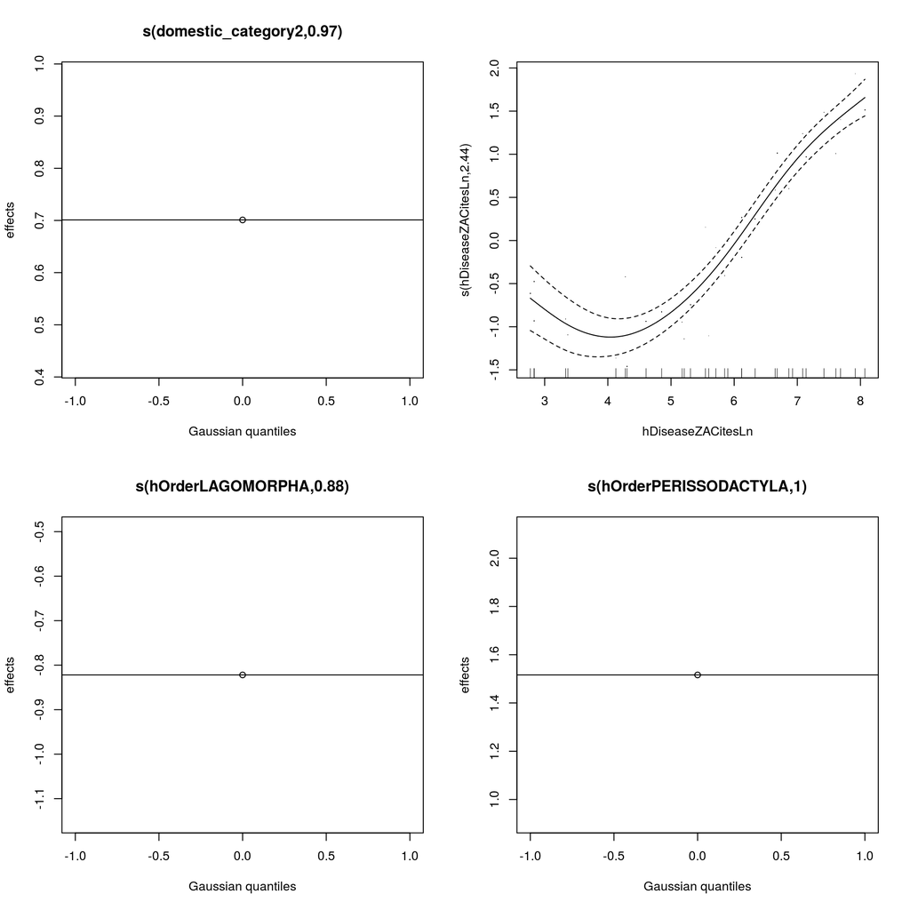

Summary of top model:

```
##
## Family: poisson
## Link function: log
##
## Formula:
## TotVirusPerHost ~ s(domestic_category2, bs = "re") + s(hDiseaseZACitesLn,
##     bs = "tp", k = 7) + s(hOrderLAGOMORPHA, bs = "re") + s(hOrderPERISSODACTYLA,
##     bs = "re")
##
## Parametric coefficients:
##             Estimate Std. Error z value Pr(>|z|)
## (Intercept)  1.95531    0.08373   23.35   <2e-16 ***
## ---
## Signif. codes:  0 '***' 0.001 '**' 0.01 '*' 0.05 '.' 0.1 ' ' 1
##
## Approximate significance of smooth terms:
##                            edf Ref.df   Chi.sq  p-value
## s(domestic_category2)   0.9656      1   82.575 2.71e-13 ***
## s(hDiseaseZACitesLn)    2.4410      6 8094.770  < 2e-16 ***
## s(hOrderLAGOMORPHA)     0.8752      1    6.812  0.00636 **
## s(hOrderPERISSODACTYLA) 1.0000      1  137.226  < 2e-16 ***
## ---
## Signif. codes:  0 '***' 0.001 '**' 0.01 '*' 0.05 '.' 0.1 ' ' 1
##
## R-sq.(adj) =  0.953   Deviance explained = 94.2%
## UBRE = 0.47854  Scale est. = 1         n = 32
```

Relative fraction of deviance explained by each variable in the top model:

| Term | Relative Deviance Explained |
| --- | --- |
| domestic_category2 | 9.98% |
| hDiseaseZACitesLn | 72.4% |
| hOrderLAGOMORPHA | 1.61% |
| hOrderPERISSODACTYLA | 16% |

10-fold cross-validation. Good fit indicated by *non*-significant p-values:

| Fold | Observations Fit | Observations Held Out | P-value | Mean Error |
| --- | --- | --- | --- | --- |
| 1 | 28 | 4 | 0.248 | -1.3068071 |
| 2 | 28 | 4 | 0.000 | 4.0357625 |
| 3 | 29 | 3 | 0.000 | -8.8075012 |
| 4 | 29 | 3 | 0.499 | -3.8318981 |
| 5 | 29 | 3 | 0.000 | 9.6955876 |
| 6 | 29 | 3 | 0.750 | -1.1155114 |
| 7 | 29 | 3 | 0.000 | -4.7601992 |
| 8 | 29 | 3 | 0.498 | 0.9179496 |
| 9 | 29 | 3 | 0.501 | 0.3652101 |
| 10 | 29 | 3 | 0.748 | 0.3792041 |

# All Viruses in Domestic Animals GAM - Stringent Associations

Terms in models with ΔAIC < 2. All continuous terms effects are represented as splines, all discrete terms as random effects:

| ΔAIC | Terms in Model |
| --- | --- |
| 0.000000 | domestic_category2 + domestic_categoryOther + hDiseaseZACitesLn + hOrderPERISSODACTYLA + hOrderRODENTIA |
| 1.374724 | domestic_category2 + hDiseaseZACitesLn + hOrderPERISSODACTYLA + hOrderRODENTIA |

Partial effect plots of all terms in top model:

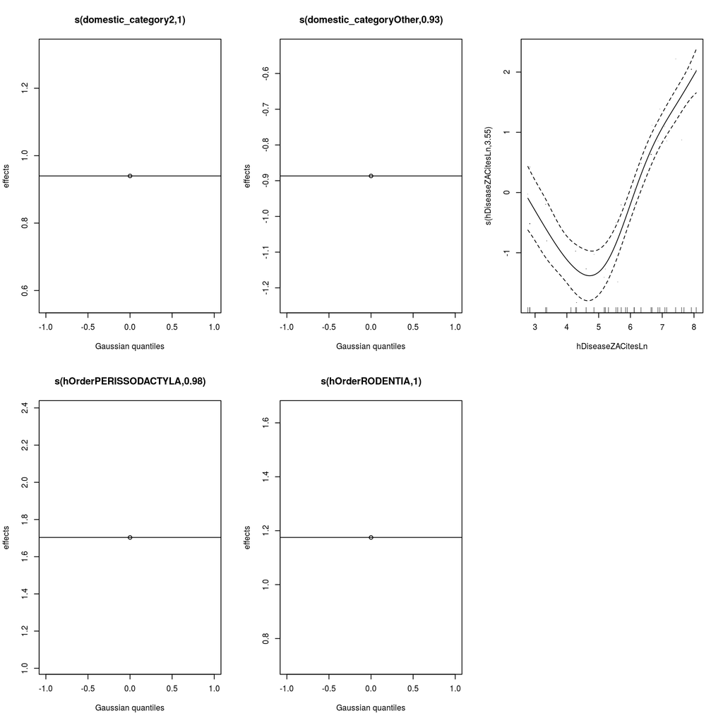

Summary of top model:

```
##
## Family: poisson
## Link function: log
##
## Formula:
## TotVirusPerHost_strict ~ s(domestic_category2, bs = "re") + s(domestic_categoryOther,
##     bs = "re") + s(hDiseaseZACitesLn, bs = "tp", k = 7) + s(hOrderPERISSODACTYLA,
##     bs = "re") + s(hOrderRODENTIA, bs = "re")
##
## Parametric coefficients:
##             Estimate Std. Error z value Pr(>|z|)
## (Intercept)    1.090      0.141   7.731 1.07e-14 ***
## ---
## Signif. codes:  0 '***' 0.001 '**' 0.01 '*' 0.05 '.' 0.1 ' ' 1
##
## Approximate significance of smooth terms:
##                              edf Ref.df    Chi.sq  p-value
## s(domestic_category2)     1.0000      1    110.64 3.81e-09 ***
## s(domestic_categoryOther) 0.9336      1    214.34 0.016014 *
## s(hDiseaseZACitesLn)      3.5543      6 760224.93 7.98e-07 ***
## s(hOrderPERISSODACTYLA)   0.9789      1     81.35 1.57e-15 ***
## s(hOrderRODENTIA)         1.0000      1    427.47 0.000549 ***
## ---
## Signif. codes:  0 '***' 0.001 '**' 0.01 '*' 0.05 '.' 0.1 ' ' 1
##
## R-sq.(adj) =  0.908   Deviance explained = 91.8%
## UBRE = 0.62949  Scale est. = 1         n = 32
```

Relative fraction of deviance explained by each variable in the top model:

| Term | Relative Deviance Explained |
| --- | --- |
| domestic_category2 | 11.3% |
| domestic_categoryOther | 1.85% |
| hDiseaseZACitesLn | 68.4% |
| hOrderPERISSODACTYLA | 15% |
| hOrderRODENTIA | 3.47% |

10-fold cross-validation. Good fit indicated by *non*-significant p-values:

| Fold | Observations Fit | Observations Held Out | P-value | Mean Error |
| --- | --- | --- | --- | --- |
| 1 | 28 | 4 | 0.749 | -0.0889347 |
| 2 | 28 | 4 | 0.876 | 0.4056110 |
| 3 | 29 | 3 | 0.251 | -6.6005473 |
| 4 | 29 | 3 | 0.249 | 1.3773346 |
| 5 | 29 | 3 | 0.499 | -0.8342990 |
| 6 | 29 | 3 | 0.000 | 1.1021046 |
| 7 | 29 | 3 | 0.750 | 0.9422361 |
| 8 | 29 | 3 | 0.000 | 12.5596416 |
| 9 | 29 | 3 | 0.502 | 4.1044873 |
| 10 | 29 | 3 | 0.749 | -0.0981216 |